# Data Challenge 5

## Data Science I 2020

For this assignment we will be using publicly avaliable data from AirBnB to make 5 original paper quality figures with captions using python! We will focus on the packages numpy, matplotlib, seaborn, and pandas. We will access the AirBnB data at http://insideairbnb.com/get-the-data.html. You can pick any city of your choosing for this analysis --- please only pick one city.

A few requirements for the figures:

- Use at least five distinct plot types (i.e. histogram, scatterplot, barplot, stacked barplot, ...)
- At least two figures should use a change of color from the default matplotlib or seaborn colors
- At least one figure should use 'pd.merge' to join two of the dataframes together
- All plots should have a title, axis labels, and legend titles
- Variable names are not acceptable for axis labels and legend labels
- Figure captions should be three to five sentences and describe the figure and trends in the data.

You will submit this assignment as an html file on Canvas. The code from your assignment should be visible in the html that you submit. Submit your .ipynb file to a GitHub repository and include a link to the repository at the top of the html that you submit on Canvas. Make the repository private and invite the instructor and both of the TAs to your repository.

The rubric for grading is shown below. The assignment is worth **100 pts**.

- **Code Style (10 pts)** Is code organized well and commented?
- **Submission (10 pts)** Was the data challenge submitted as an html document on Canvas? Did the html document contain code and written explanations of results? Does the html document look aesthetically pleasing? Did the homework contain a link for a GitHub repository? Did the repository contain the code for the assignment?
- **Overall Instructions (10 pts)** Were the above overall requirements satisfied for the plots (five types of plots, using a merge etc.)?
- **Figure (10 pts each = 50 pts total)** Does each figure tell a compelling and understandable story from the data? Does each figure have a title? Were variable names not used for axis and legend?
- **Captions (4 pts each = 20 pts total)** Quality of figure captions. Are the captions well written? Do they describe the plot and some of the trend in the data?

Example code and an example figure are shown below (do not use this figure as part of your assignment – that would be plagiarism!). Note the detail of the code comments. Also note how the caption explains what is going on in the figure while also interpreting some of the trend in the data. This will be expected from your code and caption.

```python
## load in the required packages
import pandas as pd
import matplotlib.pyplot as plt
```

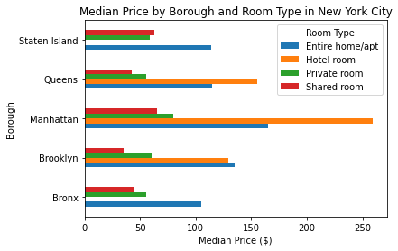

```python
## read in the data
listings = pd.read_csv('listings.csv')

## horizontal bar plot of the median price by borough and room type
listings.groupby(['neighbourhood_group',
                  'room_type'])['price'].median().unstack().plot.barh()

plt.xlabel('Median Price ($)') ## change x label
plt.ylabel('Borough') ## change y label
plt.title('Median Price by Borough and Room Type in New York City') ## add title
plt.legend(title = 'Room Type') ## change title of legend
```

Figure 1: This plot shows the median price for one night of different types of AirBnB listings by New York City borough. Hotel rooms in Manhattan have the largest median price, followed by renting an entire home or apartment in Manhattan. The least expensive median price is a shared room in Brooklyn.